## Functions

```
library(tidyverse)
```

### 1. Logical operations

**Logical AND**

```r
TRUE & TRUE
```

```
## [1] TRUE
```

```r
TRUE & FALSE
```

```
## [1] FALSE
```

```r
FALSE & TRUE
```

```
## [1] FALSE
```

```r
FALSE & FALSE
```

```
## [1] FALSE
```

**Logical OR**

```r
TRUE | TRUE
```

```
## [1] TRUE
```

```r
TRUE | FALSE
```

```
## [1] TRUE
```

```r
FALSE | TRUE
```

```
## [1] TRUE
```

```r
FALSE | FALSE
```

```
## [1] FALSE
```

**Logical NEG**

```r
!TRUE
```

```
## [1] FALSE
```

```r
!FALSE
```

```
## [1] TRUE
```

**Comparison**

```r
2 == 2
```

```
## [1] TRUE
```

```r
2 == 5
```

```
## [1] FALSE
```

```r
2 != 5
```

```
## [1] TRUE
```

```r
2 != c(2, 3)
```

```
## [1] FALSE  TRUE
```

```r
'flower' == 'rose'
```

```
## [1] FALSE
```

```r
'rose' == 'rose'
```

```
## [1] TRUE
```

```r
c(2,3) == c(2,3)
```

```
## [1] TRUE TRUE
```

```r
c(2,5) == c(2,3)
```

```
## [1]  TRUE FALSE
```

### 2. Creating your own functions

```r
n_syllables <- function(x){
  stringr::str_count(x, "[АОУЁЕЭЯИЮаоуёеэяию]")
}

n_syllables("корова")
```

```
## [1] 3
```

```r
n_syllables("слон")
```

```
## [1] 1
```

Functions depend on the packages that are loaded, you might want to indicate the necessary package explicitly:

```r
n_syllables <- function(x){
  stringr::str_count(x, "[АОУЁЕЭЯИЮаоуёеэяию]")
}
```

Recursion:

```r
factorial <- function(x){
  if(x-1 > 0){
    x*factorial(x-1)
  } else {
    1
  }
}

factorial(3)
```

```
## [1] 6
```

```r
factorial(4)
```

```
## [1] 24
```

```r
factorial(8)
```

```
## [1] 40320
```

```r
factorial(0)
```

```
## [1] 1
```

Problem 1:

create a function that will compare the length of two words and tell which one is longer.

To test:

```
which_is_longer("роза", "цветок")
which_is_longer("олень", "палка")
which_is_longer("воробей", "птица")
which_is_longer("boat", "sea")
```

### The use of conditions

Let’s take [the data on the UK pubs](https://raw.githubusercontent.com/dashapopova/Intro-to-R/main/HWs/HW2/UK_pubs.csv). Some of the pub names have *Inn* as part of them. Let’s plot twenty most common pubs with *Inn* in their names and without *Inn* in their names.

```r
library("dplyr")
library("tidyverse")
```

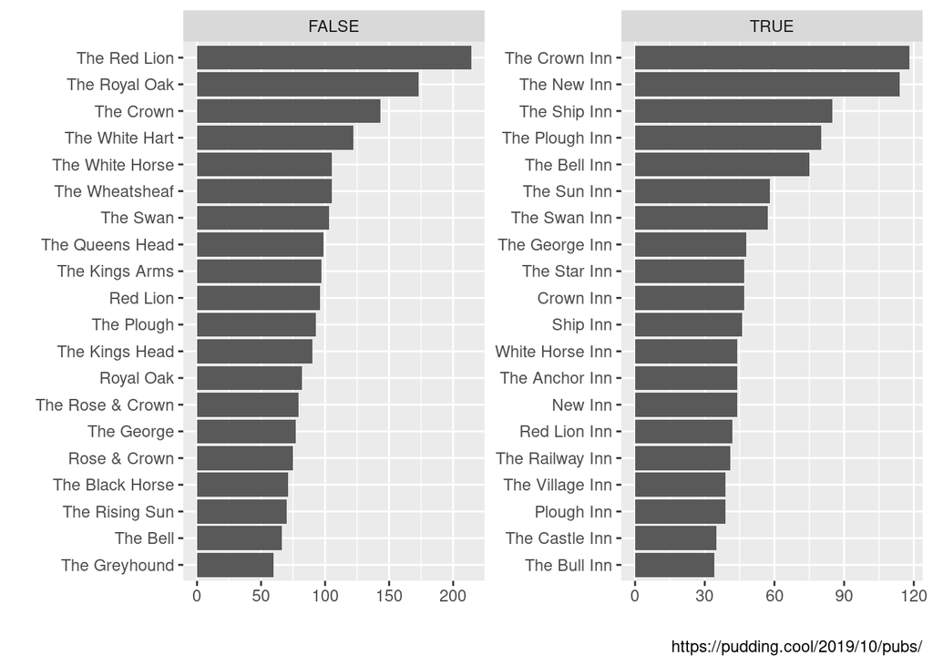

```r
uk_pubs <- read.csv("https://raw.githubusercontent.com/dashapopova/Intro-to-R/main/HWs/HW2/UK_pubs.csv")
uk_pubs %>%
  count(pub_name, sort = TRUE) %>%
  mutate(inn = str_detect(pub_name, "Inn")) %>%
  group_by(inn) %>%
  slice(1:20) %>%
  ggplot(aes(fct_reorder(pub_name, n), n))+
  geom_col()+
  coord_flip()+
  facet_wrap(~inn, scale = "free")+
  labs(x = "", y = "", caption = "https://pudding.cool/2019/10/pubs/")
```

We got what we wanted, but the names TRUE and FALSE are not very appealing. We can rectify the situation by using `ifelse()` function that has three arguments:

- condition,
- the value if the condition takes the value TRUE,
- the value if the condition takes the value FALSE.

```r
ifelse(2+2 == 4, "correct", "incorrect")
```

```
## [1] "correct"
```

```r
ifelse(2+2 == 5, "correct", "incorrect")
```

```
## [1] "incorrect"
```

Let’s modify our initial code using this function:

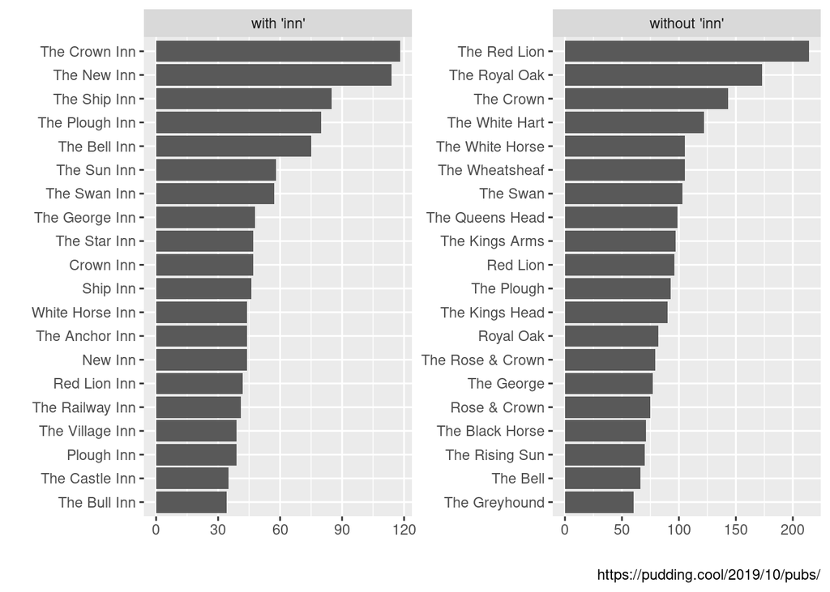

```r
uk_pubs %>%
  count(pub_name, sort = TRUE) %>%
  mutate(inn = ifelse(str_detect(pub_name, "Inn"),
                      "with 'inn'",
                      "without 'inn'")) %>%
  group_by(inn) %>%
  slice(1:20) %>%
  ggplot(aes(fct_reorder(pub_name, n), n))+
  geom_col()+
  coord_flip()+
  facet_wrap(~inn, scale = "free")+
  labs(x = "", y = "", caption = "https://pudding.cool/2019/10/pubs/")
```

What if there are more conditions?

```
case_when(
  condition 1 ~ value x,
  condition 2 ~ value y,
  ...
  condition n ~ value z
)
```

Let’s look for more type of names: with *Inn*, *Hotel*, *Bar*, *House* and *Tavern*:

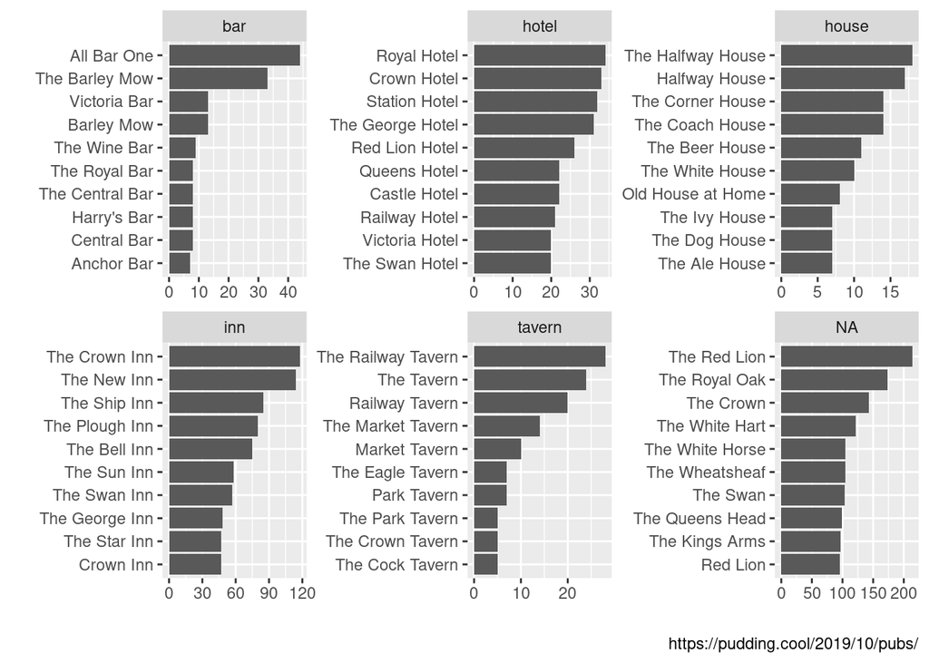

```r
uk_pubs %>%
  count(pub_name, sort = TRUE) %>%
  mutate(place = case_when(
    str_detect(pub_name, "Inn") ~ "inn",
    str_detect(pub_name, "Hotel") ~ "hotel",
    str_detect(pub_name, "Bar") ~ "bar",
    str_detect(pub_name, "House") ~ "house",
    str_detect(pub_name, "Tavern") ~ "tavern")) %>%
  group_by(place) %>%
  slice(1:10) %>%
  ggplot(aes(fct_reorder(pub_name, n), n))+
  geom_col()+
  coord_flip()+
  facet_wrap(~place, scale = "free")+
  labs(x = "", y = "", caption = "https://pudding.cool/2019/10/pubs/")
```

What does the NA variant stand for?

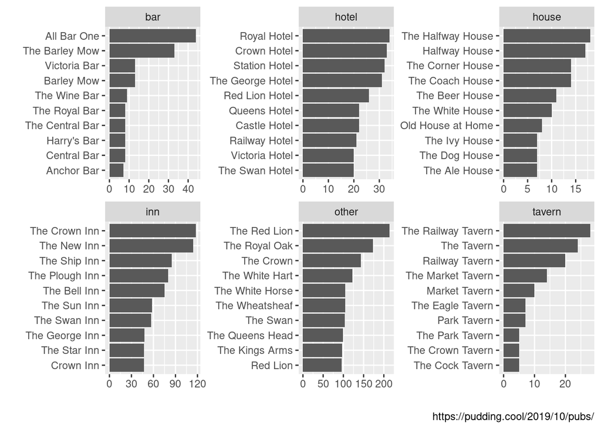

```r
uk_pubs %>%
  count(pub_name, sort = TRUE) %>%
  mutate(place = case_when(
    str_detect(pub_name, "Inn") ~ "inn",
    str_detect(pub_name, "Hotel") ~ "hotel",
    str_detect(pub_name, "Bar") ~ "bar",
    str_detect(pub_name, "House") ~ "house",
    str_detect(pub_name, "Tavern") ~ "tavern",
    TRUE ~ "other")) %>%
  group_by(place) %>%
  slice(1:10) %>%
  ggplot(aes(fct_reorder(pub_name, n), n))+
  geom_col()+
  coord_flip()+
  facet_wrap(~place, scale = "free")+
  labs(x = "", y = "", caption = "https://pudding.cool/2019/10/pubs/")
```

What if you want to apply `summarise()` or `mutate()` only to some columns? For that, there are functions `summarise_at()` or `mutate_at()`. For instance, let’s compute the mean for every column of the dataset `iris` that start with the word *Sepal*.

```r
iris %>%
  head()
```

```
##   Sepal.Length Sepal.Width Petal.Length Petal.Width Species
## 1          5.1         3.5          1.4         0.2  setosa
## 2          4.9         3.0          1.4         0.2  setosa
## 3          4.7         3.2          1.3         0.2  setosa
## 4          4.6         3.1          1.5         0.2  setosa
## 5          5.0         3.6          1.4         0.2  setosa
## 6          5.4         3.9          1.7         0.4  setosa
```

```r
iris %>%
  summarise_at(vars(starts_with("Sepal")), mean)
```

```
##   Sepal.Length Sepal.Width
## 1     5.843333    3.057333
```

```r
iris %>%
  summarise_at(vars(matches("Sepal")), mean) #corresponds to a regular expression
```

```
##   Sepal.Length Sepal.Width
## 1     5.843333    3.057333
```

```r
iris %>%
  summarise_at(vars(ends_with("Width")), mean)
```

```
##   Sepal.Width Petal.Width
## 1    3.057333    1.199333
```

```r
diamonds %>%
  summarise_at(vars(one_of(c("depth", "price", "carat"))), mean)
```

```
## # A tibble: 1 × 3
##   depth price carat
##   <dbl> <dbl> <dbl>
## 1  61.7 3933. 0.798
```

```r
diamonds %>%
  summarise_if(is.numeric, mean)
```

```
## # A tibble: 1 × 7
##   carat depth table price     x     y     z
##   <dbl> <dbl> <dbl> <dbl> <dbl> <dbl> <dbl>
## 1 0.798  61.7  57.5 3933.  5.73  5.73  3.54
```

More examples:

```r
diamonds
```

```
## # A tibble: 53,940 × 10
##    carat cut       color clarity depth table price     x     y     z
##    <dbl> <ord>     <ord> <ord>   <dbl> <dbl> <int> <dbl> <dbl> <dbl>
##  1  0.23 Ideal     E     SI2      61.5    55   326  3.95  3.98  2.43
##  2  0.21 Premium   E     SI1      59.8    61   326  3.89  3.84  2.31
##  3  0.23 Good      E     VS1      56.9    65   327  4.05  4.07  2.31
##  4  0.29 Premium   I     VS2      62.4    58   334  4.2   4.23  2.63
##  5  0.31 Good      J     SI2      63.3    58   335  4.34  4.35  2.75
##  6  0.24 Very Good J     VVS2     62.8    57   336  3.94  3.96  2.48
##  7  0.24 Very Good I     VVS1     62.3    57   336  3.95  3.98  2.47
##  8  0.26 Very Good H     SI1      61.9    55   337  4.07  4.11  2.53
##  9  0.22 Fair      E     VS2      65.1    61   337  3.87  3.78  2.49
## 10  0.23 Very Good H     VS1      59.4    61   338  4     4.05  2.39
## # … with 53,930 more rows
```

```r
diamonds %>%
  mutate_at(vars(one_of(c("depth", "price", "carat"))), sqrt)
```

```
## # A tibble: 53,940 × 10
##    carat cut       color clarity depth table price     x     y     z
##    <dbl> <ord>     <ord> <ord>   <dbl> <dbl> <dbl> <dbl> <dbl> <dbl>
##  1 0.480 Ideal     E     SI2      7.84    55  18.1  3.95  3.98  2.43
##  2 0.458 Premium   E     SI1      7.73    61  18.1  3.89  3.84  2.31
##  3 0.480 Good      E     VS1      7.54    65  18.1  4.05  4.07  2.31
##  4 0.539 Premium   I     VS2      7.90    58  18.3  4.2   4.23  2.63
##  5 0.557 Good      J     SI2      7.96    58  18.3  4.34  4.35  2.75
##  6 0.490 Very Good J     VVS2     7.92    57  18.3  3.94  3.96  2.48
##  7 0.490 Very Good I     VVS1     7.89    57  18.3  3.95  3.98  2.47
##  8 0.510 Very Good H     SI1      7.87    55  18.4  4.07  4.11  2.53
##  9 0.469 Fair      E     VS2      8.07    61  18.4  3.87  3.78  2.49
## 10 0.480 Very Good H     VS1      7.71    61  18.4  4     4.05  2.39
## # … with 53,930 more rows
```

```r
diamonds %>%
  mutate_if(is.numeric, sqrt)
```

```
## # A tibble: 53,940 × 10
##    carat cut       color clarity depth table price     x     y     z
##    <dbl> <ord>     <ord> <ord>   <dbl> <dbl> <dbl> <dbl> <dbl> <dbl>
##  1 0.480 Ideal     E     SI2      7.84  7.42  18.1  1.99  1.99  1.56
##  2 0.458 Premium   E     SI1      7.73  7.81  18.1  1.97  1.96  1.52
##  3 0.480 Good      E     VS1      7.54  8.06  18.1  2.01  2.02  1.52
##  4 0.539 Premium   I     VS2      7.90  7.62  18.3  2.05  2.06  1.62
##  5 0.557 Good      J     SI2      7.96  7.62  18.3  2.08  2.09  1.66
##  6 0.490 Very Good J     VVS2     7.92  7.55  18.3  1.98  1.99  1.57
##  7 0.490 Very Good I     VVS1     7.89  7.55  18.3  1.99  1.99  1.57
##  8 0.510 Very Good H     SI1      7.87  7.42  18.4  2.02  2.03  1.59
##  9 0.469 Fair      E     VS2      8.07  7.81  18.4  1.97  1.94  1.58
## 10 0.480 Very Good H     VS1      7.71  7.81  18.4  2     2.01  1.55
## # … with 53,930 more rows
```

You can also use your own function:

```r
iris %>%
  summarise_at(vars(matches("Sepal")), function(x){mean(x)*min(x)})
```

```
##   Sepal.Length Sepal.Width
## 1     25.12633    6.114667
```

Solution to problem 1

```r
which_is_longer <- function(x,y){
  if(stringr::str_count(x, "[A-zА-я]")>stringr::str_count(y, "[A-zА-я]")){
    "the first word is longer"
  } else if (stringr::str_count(x, "[A-zА-я]")<stringr::str_count(y, "[A-zА-я]")){
    "the second word is longer"
  } else {
  "the words are of the same length"
  }
}

which_is_longer("роза", "цветок")
```

```
## [1] "the second word is longer"
```

```r
which_is_longer("олень", "палка")
```

```
## [1] "the words are of the same length"
```

```r
which_is_longer("воробей", "птица")
```

```
## [1] "the first word is longer"
```

```r
which_is_longer("boat", "sea")
```

```
## [1] "the first word is longer"
```